# R Notebook

# Chapter 8. ggplot2

Exploratory Data Visulization은 R의 강점이다. 유연함과 동시에 간편하고 빠르다. **ggplot2** package를 통해 이를 실행할 수 있다.

사전 준비

```r
library(dplyr)
library(ggplot2)
```

R의 기본 함수만으로도 plotting은 상당한 수준으로 가능하다. **grid**와 **lattice** 패키지로도 가능하다. **ggplot2**를 사용하는 이유는 plot의 각각의 요소들을 나누어서 설정할 수 있게 해주고, 그 과정이 매우 직관적이고 기억하기 쉽기 때문이다.

**ggplot2**가 직관적인 이유는 **G**rammer of **G**raphic 때문이다. 초보자들도 몇개의 명령어를 통해서 쉽게 수십가지의 plot 디자인이 가능하다. 그리고 대부분의 상황에 적합한 plot을 만들 수 있다. informative and elegant graphs라는데 글쎄… 일단 보자.

한계점은 이것이 tidy format에만 작용한다는 것이다. 그러나 이것도 대부분 전환 가능하니 문제는 딱히 없다.

**ggplot2**를 사용할 때는 몇개의 함수와 문장을 알아야 한다. 외우기 어려우므로, ggplot2 sheet cheat를 찾아서 보자. https://www.rstudio.com/wp-content/uploads/2015/03/ggplot2-cheatsheet.pdf

# 8.1 The Components of a Graph

ggplot2를 배우기 위한 첫 단계는 각각의 요소를 나눠서 보는 것이다. > Data : US murder D.T.는 요약된 Data 라고 할 수 있다. > Geometry : scatterplot, barplot, histogram, smooth densities, qqplot, boxplot 등의 형태를 말한다. > Aesthetic mapping : plot은 몇개의 visual cue를 제시한다. x, y 축의 스케일, 색, 등을 말한다. 엑셀의 범례 부분과 유사하다.

> > 각 포인트는 약자로 표기한다. x, y 축의 범위는 data의 그것과 동일하며, 로그 스케일이다. Economist Magazine의 스타일과 비슷하게 맞춘다.

```r
library(dslabs)
data(murders)
```

# 8.2 ggplot objects

가장 먼저 하는 것은 `ggplot` 오브젝트를 지정하는 것이다. 이는 두가지 방식으로 지정 가능하다.

```r
ggplot(data = murders)
```

[output not shown]

```r
#murders %>% ggplot()
```

```r
p <- ggplot(data = murders)
class(p)
```

```
[1] "gg"     "ggplot"
```

```r
# 아래 두 라인은 동일한 것을 출력한다.
print(p)
```

[output not shown]

```r
p
```

[output not shown]

# 8.3 Geometries

`ggplot2`에서는 그래프를 layer를 추가하면서 만든다. 각 레이어에서는 geometry, summary, scale, style이 모두 조작 가능하다. 레이어는 +로 추가한다. >DATA %>% ggplot() + A + B…

대부분 첫 레이어는 geometry이다. scatter plot을 만들기 위해서는 `geom_point`가 필요하다. geometry 함수는 geom_x의 형식이다. 예로는 `geom_bar`가 있다. 참고해두자. murders 테이블은 이미 p 오브젝트에 들어간 상태이다. 그리고 **Aesthetics**를 통해 두개 이상의 argument 가 필요함을 알 수 있다.

# 8.4 Aesthetic mappings

**Aesthetic mappings**는 데이터가 그래프에 어떻게 들어가는지 설정해준다. 스케일이나 축의 색 따위가 있다. `aes` 함수로 가능하다. 그리고 그 출력은 geometry 함수의 argument로 쓰인다.

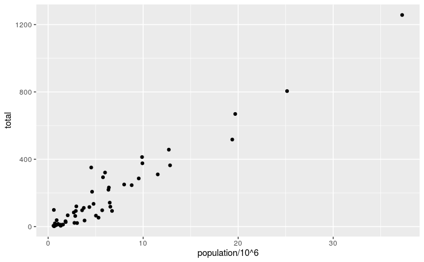

```r
murders %>% ggplot() + geom_point(aes(x = population/10^6, y = total))
```

```r
# p + geom_point(aes(population/10^6, total))
```

**dplyr** 함수처럼 이 함수들도 데이터 이름 없이 column 이름만 써도 된다. 즉 $를 안써도 된다.

# 8.5 Layers

`geom_label`과 `geom_text`함수는 plot에 텍스트를 넣을 수 있게 해준다. 첫 레이어는 point의 특성이다. 두번째 레이어는 축의 특성이다. 둘 다 축이 같을 수 밖에 없다.

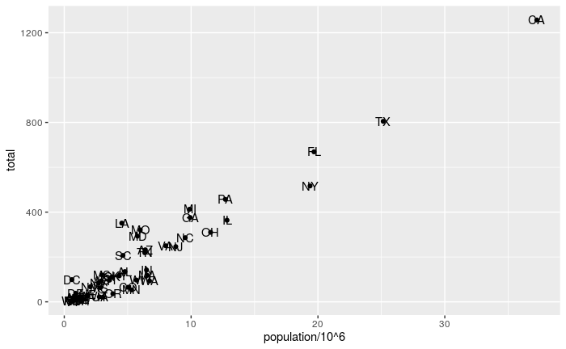

```r
p + geom_point(aes(population/10^6, total)) + geom_text(aes(population/10^6, total, label = abb))
```

## 8.5.1 Tinkering with arguments

각 geometry 함수는 많은 argument를 받을 수 있다,

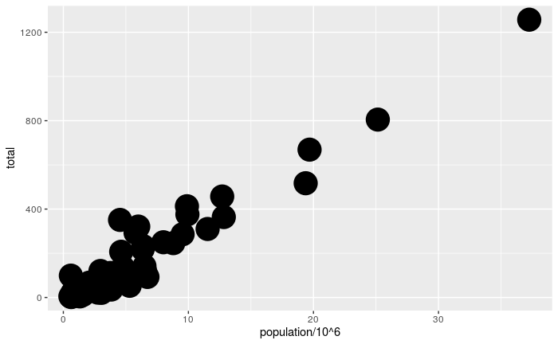

```r
p + geom_point(aes(population/10^6, total), size = 10) + geom_text(aes(population/10^6, total, label = abb))
```

`size`는 mapping이 아니다. 특정한 data를 쓰는 mapping은 aes 안에 들어가야 하지만 `size`는 일반적인 데이터를 특정하므로 그 밖에 있어도 된다.

그런데 이제는 label을 읽기가 힘들다. `nudge_x`는 텍스트를 조금 움직일 때 쓴다.

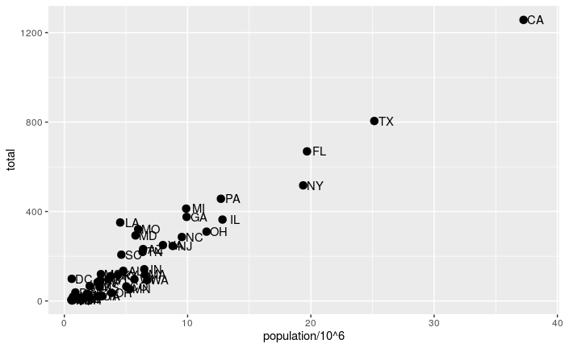

```r
p + geom_point(aes(population/10^6, total), size = 3) + geom_text(aes(population/10^6, total, label = abb), nudge_x = 1)
```

# 8.6 Global Versus local aesthetic mappings

앞선 코드에서는 같은 aes() 라인을 두번 쳤다. 이를 **global aesthetic mapping**으로 해결할 수 있다.

```r
args(ggplot)
```

```
function (data = NULL, mapping = aes(), ..., environment = parent.frame())
NULL
```

`ggplot`에 직접 mapping을 하면 이는 모든 레이어에 기본으로 들어가게 된다.

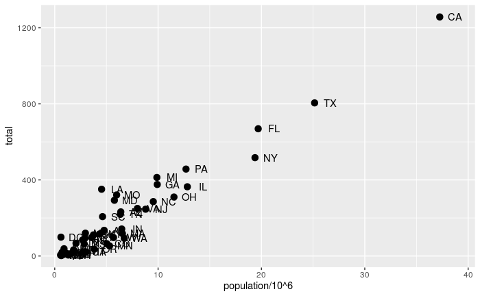

```r
p <- murders %>% ggplot(aes(population/10^6, total, label = abb))
p + geom_point(size = 3) + geom_text(nudge_x = 1.5)
```

ggplot 내에 들어간 argument 중 각 레이어의 함수가 받지 못하는게 있다면, 그냥 무시한다.

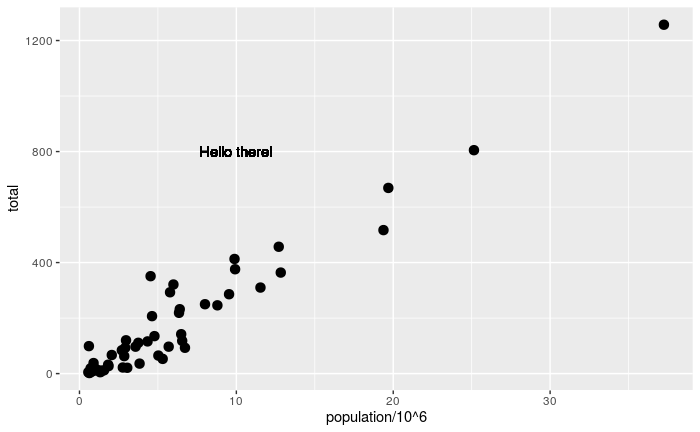

```r
p + geom_point(size = 3) +
  geom_text(aes(x = 10, y = 800, label = "Hello there!"))
```

# 8.7 Scales

축을 로그 스케일로 만드려면 scale 레이어가 필요하다. `scale_x_continuous` 함수로 가능하다.

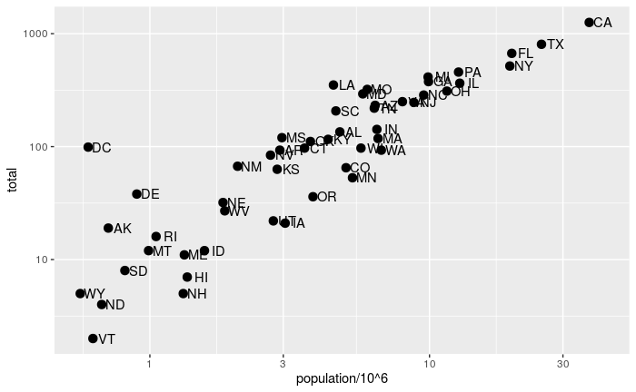

```r
p + geom_point(size = 3) +
  geom_text(nudge_x = 0.05) +
  scale_x_continuous(trans = "log10") +
  scale_y_continuous(trans = "log10")
```

로그 스케일의 경우 ggplot2에서 아예 다른 함수로 만들어줬다. `scale_x_log10()`과 `scale_y_log10()`을 쓰면 된다.

# 8.8 Labels and titles

x, y축의 레이블과 제목도 정할 수 있다. 다음 함수를 쓴다.

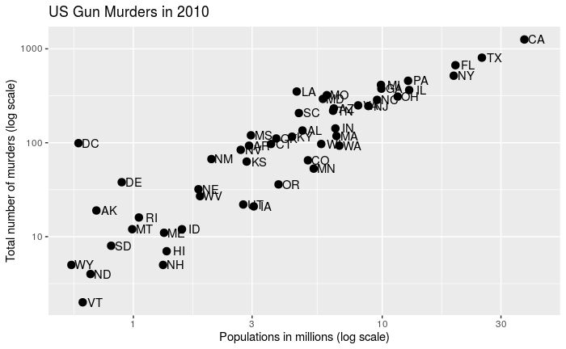

```r
p + geom_point(size = 3) +
  geom_text(nudge_x = 0.05) +
  scale_x_log10() +
  scale_y_log10() +
  xlab("Populations in millions (log scale)") +
  ylab("Total number of murders (log scale)") +
  ggtitle("US Gun Murders in 2010")
```

# 8.9 Categories as colors

`geom_point`에 `col` argument를 넣어서 각 점의 색을 바꿀 수 있다.

```r
p <-  murders %>% ggplot(aes(population/10^6, total, label = abb)) +
  geom_text(nudge_x = 0.05) +
  scale_x_log10() +
  scale_y_log10() +
  xlab("Populations in millions (log scale)") +
  ylab("Total number of murders (log scale)") +
  ggtitle("US Gun Murders in 2010")
```

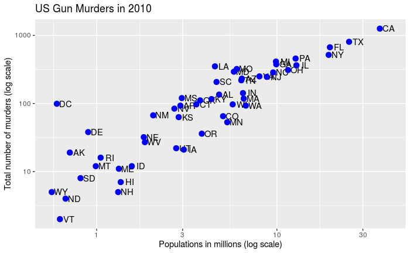

```r
p + geom_point(size = 3, color = "blue")
```

각 지역별로 색을 따로 입힐 수도 있다. ggplot2는 기본적으로 카테고리 변수를 인식하고 그에 따라 색을 바꿔줄 수 있다. 그리고 이건 Aesthetic mapping이다. 따라서,

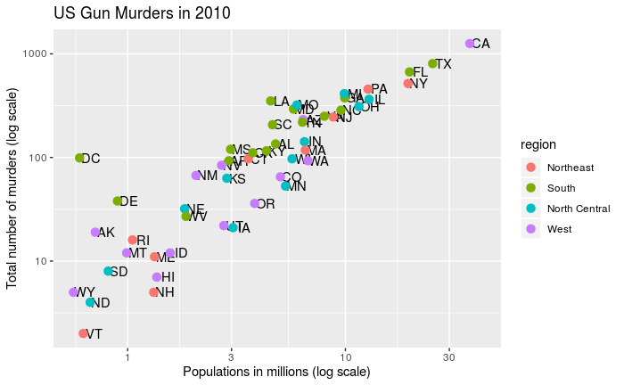

```r
p + geom_point(aes(col=region),show.legend = TRUE, size = 3)
```

gglot2는 자동으로 범례를 만들어준다. 범례는 `show.legend = FALSE’로 끌 수 있다.

# 8.10 Annotation, shapes, and adjustments

Aesthetic mapping이 없는 annotation이나 조작이 필요할 수도 있다. 미국 전체 평균을 그래프로 나타내보자. >log(y) = log(r) + log(x)

```r
r <- murders %>% summarize(rate = sum(total) / sum(population) * 10^6) %>%
  pull(rate)
```

라인을 더하는 건 `geom_abline` 함수이다. 절편과 기울기를 입력해주면 된다.

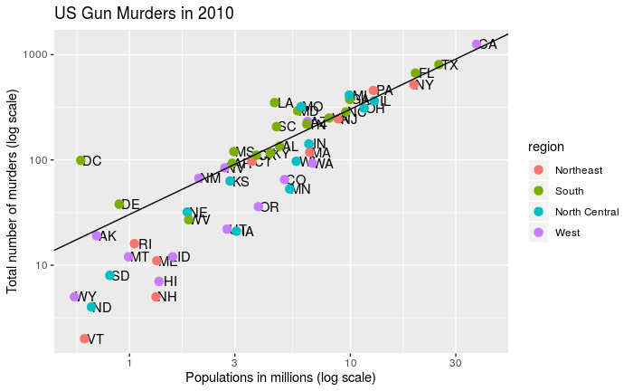

```r
p + geom_point(aes(col=region), size = 3) +
  geom_abline(intercept = log10(r))
```

당연하게도 선의 성격을 조절할 수도 있다.

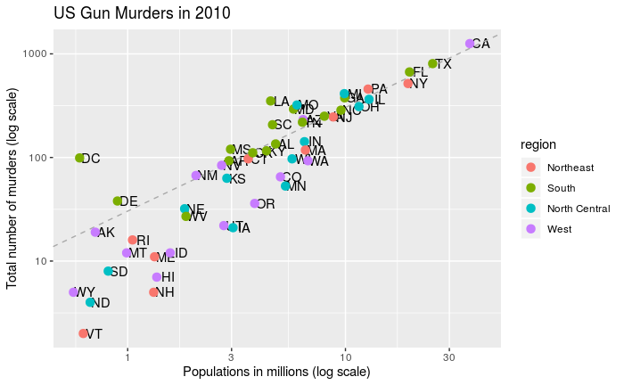

```r
p <- p + geom_abline(intercept = log10(r), lty = 2, color = "darkgrey") +
  geom_point(aes(col=region), size = 3)
p
```

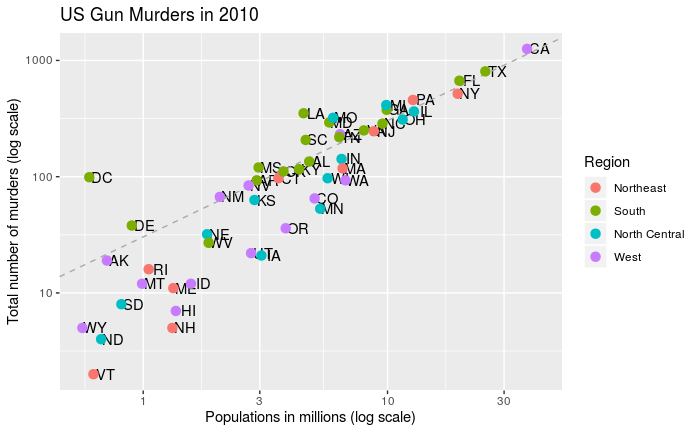

```r
p <- p + scale_color_discrete(name = "Region")
p
```

# 8.11 Add-on packages

plot의 마지막 작업은 **ggthemes**나 **ggrepel** 패키지가 필요할 수도 있다.`theme` 함수로 스타일을 바꿀 수 있다. 기본 테마로 설정해 주는 것은 dslabs에 있다.

```r
ds_theme_set()
```

ggthemes로 테마를 바꿀 수 있다.

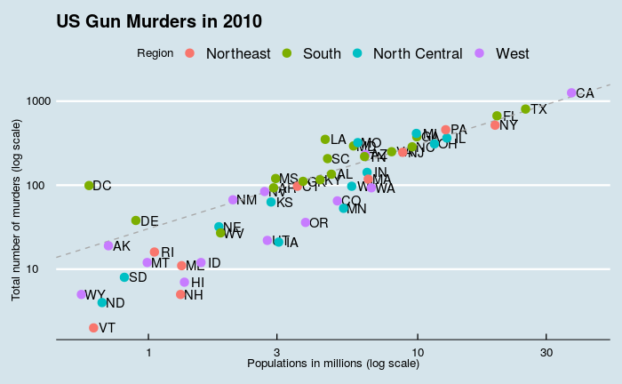

```r
#install.packages("ggthemes")
library(ggthemes)
p + theme_economist()
```

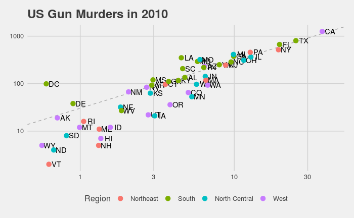

```r
#install.packages("ggthemes")
library(ggthemes)
p + theme_fivethirtyeight()
```

**ggrepel**로 각각의 텍스트가 겹치지 않게 만들 수도 있다.

# 8.12 Putting it all together

```r
#install.packages("ggrepel")
```

다 합친다.

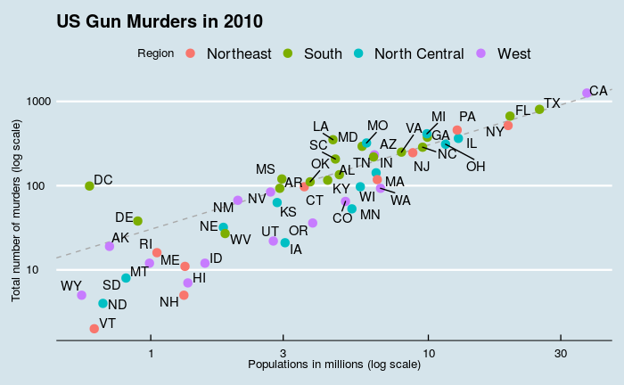

```r
library(ggthemes)
library(ggrepel)

r <- murders %>%
  summarize(rate = sum(total) /  sum(population) * 10^6) %>%
  pull(rate)

murders %>% ggplot(aes(population/10^6, total, label = abb)) +
  geom_abline(intercept = log10(r), lty = 2, color = "darkgrey") +
  geom_point(aes(col=region), size = 3) +
  geom_text_repel() +
  scale_x_log10() +
  scale_y_log10() +
  xlab("Populations in millions (log scale)") +
  ylab("Total number of murders (log scale)") +
  ggtitle("US Gun Murders in 2010") +
  scale_color_discrete(name = "Region") +
  theme_economist()
```

# 8.13 Quick plots with `qplot`

```r
data(murders)
x <- log10(murders$population)
y <- murders$total
```

이런 벡터를 가정할 때

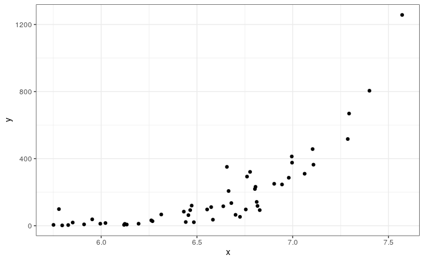

```r
data.frame(x = x, y = y) %>%
  ggplot(aes(x, y)) +
  geom_point()
```

이렇게 scatterplot을 만들 수 있다.

그러나 `qplot`을 사용하면,

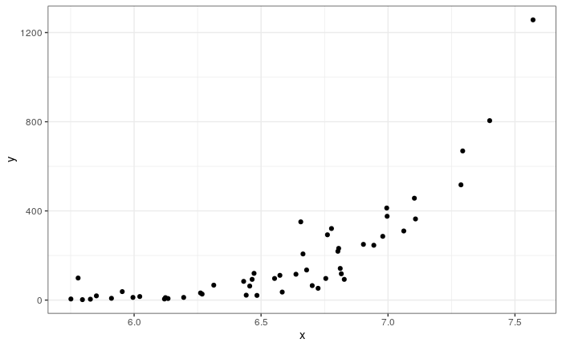

```r
qplot(x, y)
```

한줄로 된다.

# 8.14 Grid of plots

일반적인 논문의 figure처럼 여러 plot을 묶는 방법이다. **gridExtra** 패키지로 가능하다.

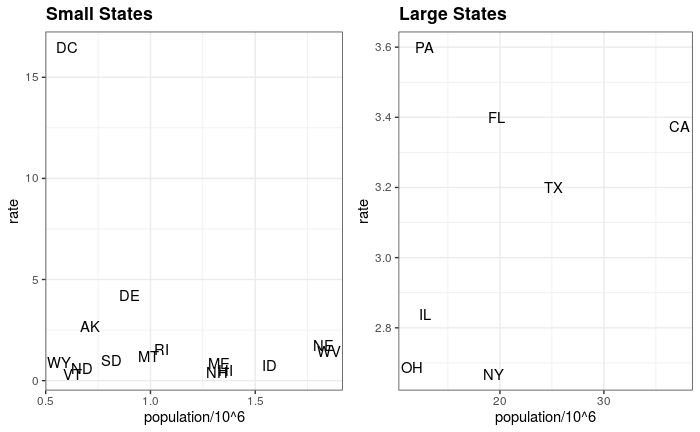

```r
install.packages("gridExtra")
library(gridExtra)
p1 <- murders %>%
  mutate(rate = total/population*10^5) %>%
  filter(population < 2*10^6) %>%
  ggplot(aes(population/10^6, rate, label = abb)) +
  geom_text() +
  ggtitle("Small States")

p2 <- murders %>%
  mutate(rate = total/population*10^5) %>%
  filter(population > 10*10^6) %>%
  ggplot(aes(population/10^6, rate, label = abb)) +
  geom_text() +
  ggtitle("Large States")

grid.arrange(p1, p2, ncol = 2)
```

# 8.15 Exercises

Start by loading the **dplyr** and **ggplot2** library as well as the murders and `heights` data.

```r
library(dplyr)
library(ggplot2)
library(dslabs)
data(heights)
data(murders)
```

## 1.With ggplot2 plots can be saved as objects. For example we can associate a dataset with a plot object like this

```r
p <- ggplot(data = murders)
```

Because data is the first argument we don’t need to spell it out

```r
p <- ggplot(murders)
```

and we can also use the pipe:

```r
p <- murders %>% ggplot()
```

What is class of the object p?

## 2.Remember that to print an object you can use the command print or simply type the object. For example

```r
x <- 2
x
print(x)
```

Print the object p defined in exercise one and describe what you see.

A. Nothing happens.

B. A blank slate plot.

C. A scatter plot.

D. A histogram.

## 3. Using the pipe %>%, create an object p but this time associated with the heights dataset instead of the murders dataset.

## 4. What is the class of the object p you have just created?

## 5. Now we are going to add a layers and the corresponding aesthetic mappings. For the murders data we plotted total murders versus population sizes. Explore the murders data frame to remind yourself what are the names for these two variables and select the correct answer. Hint: Look at ?murders.

A. state and abb.

B. total_murers and population_size.

total and population.

murders and size.

## 6. To create the scatter plot we add a layer with geom_point. The aesthetic mappings require us to define the x-axis and y-axis variables respectively. So the code looks like this:

```r
murders %>% ggplot(aes(x = , y = )) +
  geom_point()
```

except we have to define the two variables x and y. Fill this out with the correct variable names.

## 7. Note that if we don’t use argument names, we can obtain the same plot by making sure we enter the variable names in the right order like this:

```r
murders %>% ggplot(aes(population, total)) +
  geom_point()
```

Remake the plot but now with total in the x-axis and population in the y-axis.

## 8. If instead of points we want to add text, we can use the geom_text() or geom_label() geometries. The following code

```r
murders %>% ggplot(aes(population, total)) +
  geom_label()
```

will give us the error message: Error: geom_label requires the following missing aesthetics: label

Why is this?

A. We need to map a character to each point through the label argument in aes.

B. We need to let geom_label know what character to use in the plot.

C. The geom_label geometry does not require x-axis and y-axis values.

D. geom_label is not a ggplot2 command.

## 9. Rewrite the code above to abbreviation as the label through aes

## 10. Change the color of the labels through blue. How will we do this?

A. Adding a column called blue to murders

B. Because each label needs a different color we map the colors through aes

C. Use the color argument in ggplot

D. Because we want all colors to be blue, we do not need to map colors, just use the color argument in geom_label

## 11. Rewrite the code above to make the labels blue.

## 12. Now suppose we want to use color to represent the different regions. In this case which of the following is most appropriate:

A. Adding a column called color to murders with the color we want to use.

B. Because each label needs a different color we map the colors through the color argument of aes .

C. Use the color argument in ggplot.

D. Because we want all colors to be blue, we do not need to map colors, just use the color argument in geom_label.

## 13. Rewrite the code above to make the labels’ color be determined by the state’s region.

## 14. Now we are going to change the x-axis to a log scale to account for the fact the distribution of population is skewed. Let’s start by define an object p holding the plot we have made up to now

```r
p <- murders %>%
  ggplot(aes(population, total, label = abb, color = region)) +
  geom_label()
```

## 15. Repeat the previous exercise but now change both axes to be in the log scale.

## 16. Now edit the code above to add the title “Gun murder data” to the plot. Hint: use the ggtitle function.